# Exploratory Data Analysis With R by David Eraso

First Alcohol: A scatterplot using jitter, and the alpha parameter:

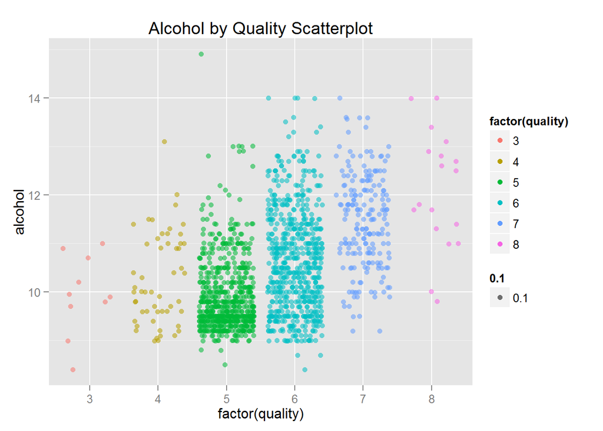

Histograms of alcohol for different qualities:

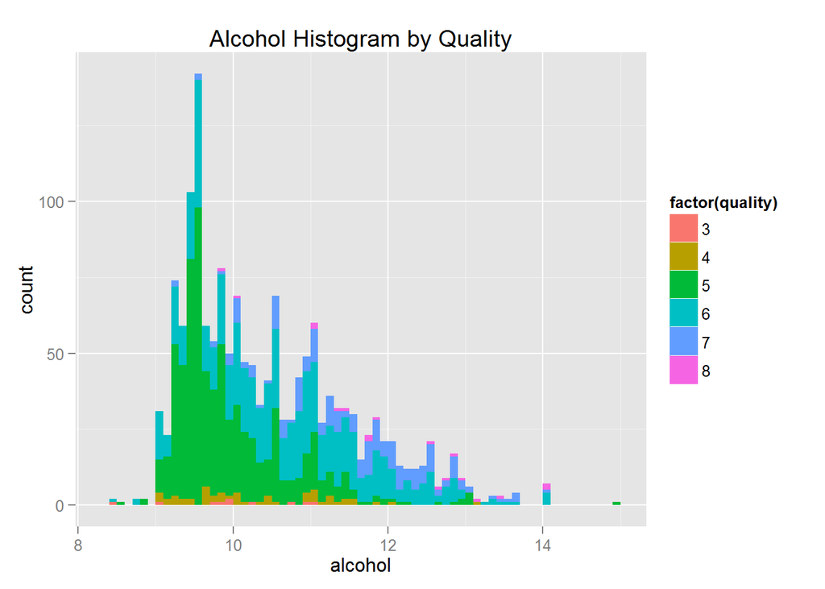

There are scores for wide values of alcohol, since most quality scores are 5 and 6, these two histograms take most of the plot area and there is not a clear cut insight. I will try boxplots.

For the boxplots by quality I turn ‘quality’, which has ‘int’ type, to a categorical varible (Ref: http://stackoverflow.com/questions/16639484/how-to-convert-integer-into-categorical-data-in-r). Also for coloring the boxplot (Ref: http://www3.nd.edu/~steve/computing_with_data/11_geom_examples/ggplot_examples.html)

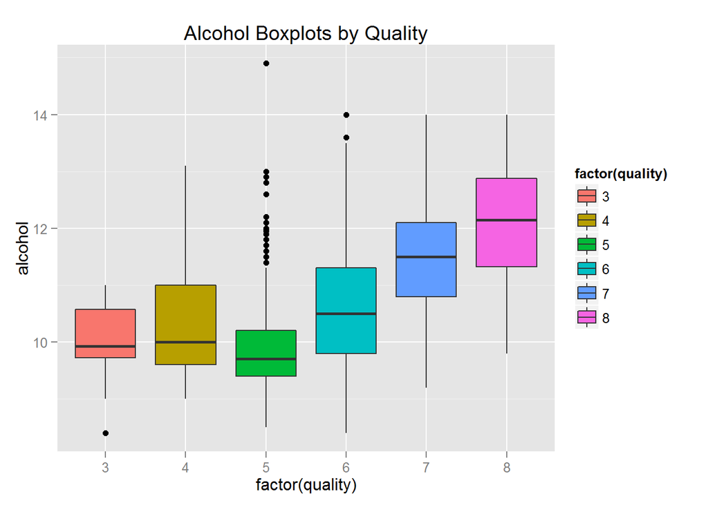

This plot is more insightful.

I will try now conditional medians. For the plot (Ref: http://www.cookbook-r.com/Graphs/Shapes_and_line_types/)

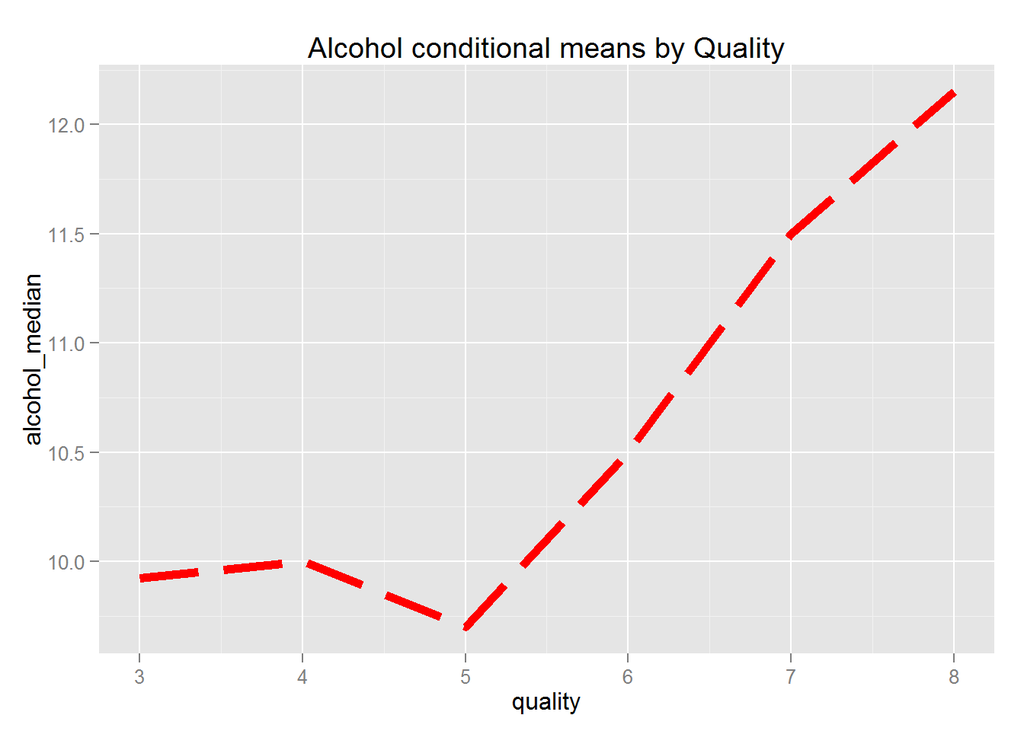

Despite the decrease from score 4 to score 5, it seems that in general, red wines with higher alcohol get higher scores.

Now, other variables of interest:

Volatile Acidity:

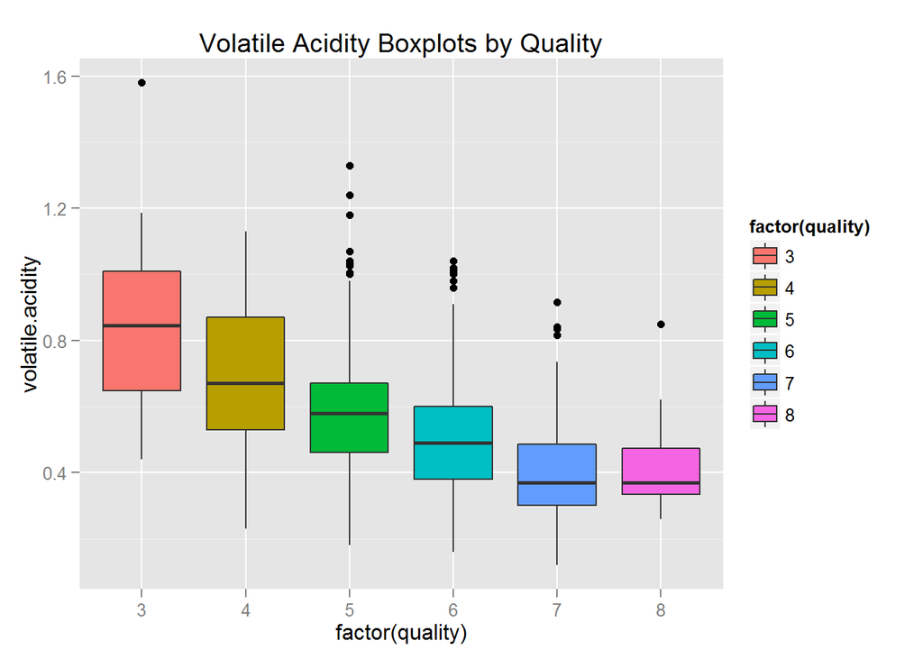

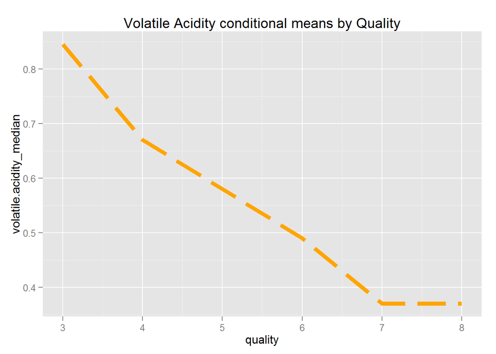

Sulphates:

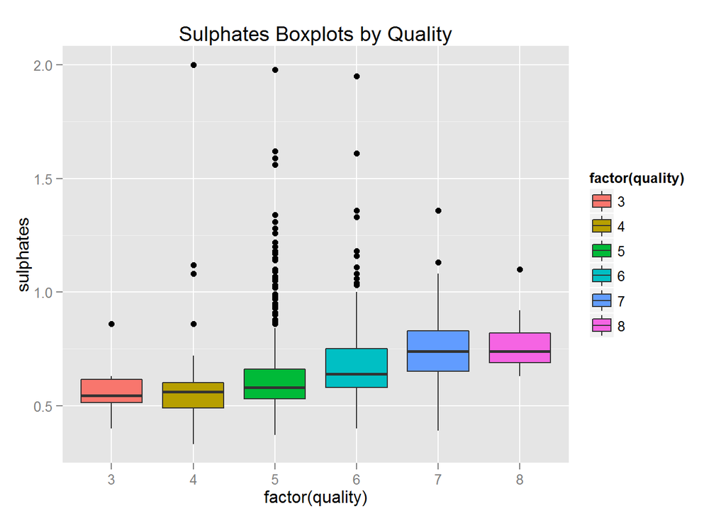

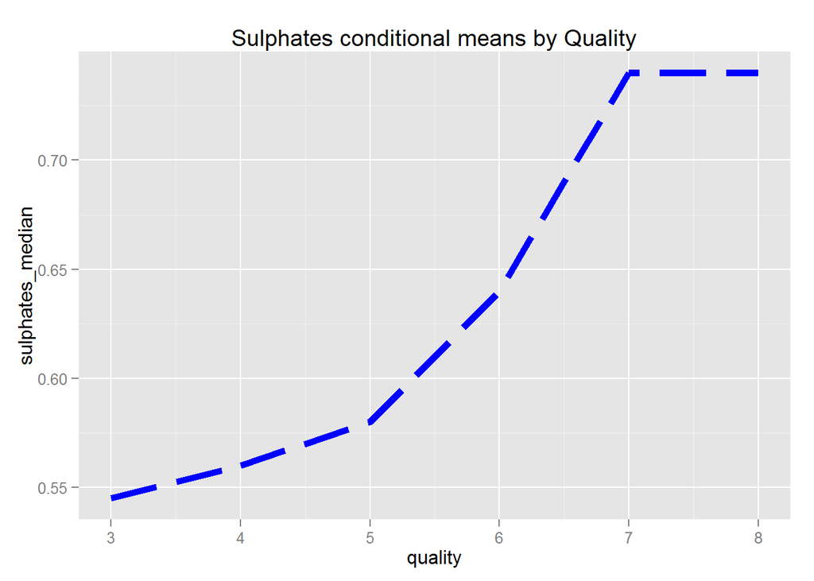

Total Sulfur Dioxide:

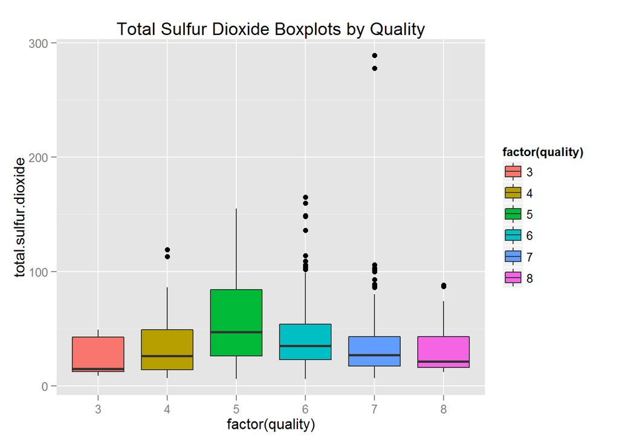

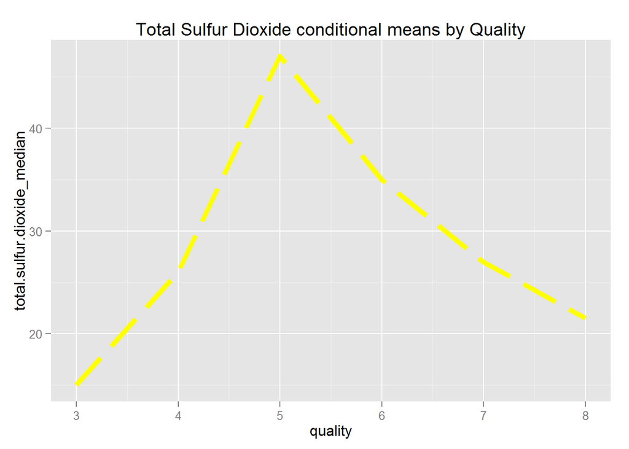

# Bivariate Analysis

### Talk about some of the relationships you observed in this part of the investigation. How did the feature(s) of interest vary with other features in the dataset?

Alcohol has a strong correlation with density; however, alcohol is the variable with the highest correlation to quality, while density has a negligible correlation with quality. The group fixed acidity, citric acid and ph are highly correlated between them. Volatile acidity has strong correlation with only citric acid from this group; interestingly it is also the ‘acidic’ variable with the strongest correlation to quality. Sulphates has a strong correlation to chlorides, but sulphates doubles its correlation to quality compared to chlorides. Free sulfur dioxide and total sulfur dioxide also have strong correlation. Both have low correlation with quality, but total sulfur dioxide had a stronger correlation; however, looking at the conditional means plot there is no clear relationship with quality.

### Did you observe any interesting relationships between the other features (not the main feature(s) of interest)?

Residual sugar has low correlation with all the other variables, including quality.

### What was the strongest relationship you found?

Fixed acidity and ph.

# Multivariate Plots Section

I will start exploring the relationship between volatile acidity, citric acid, and quality.

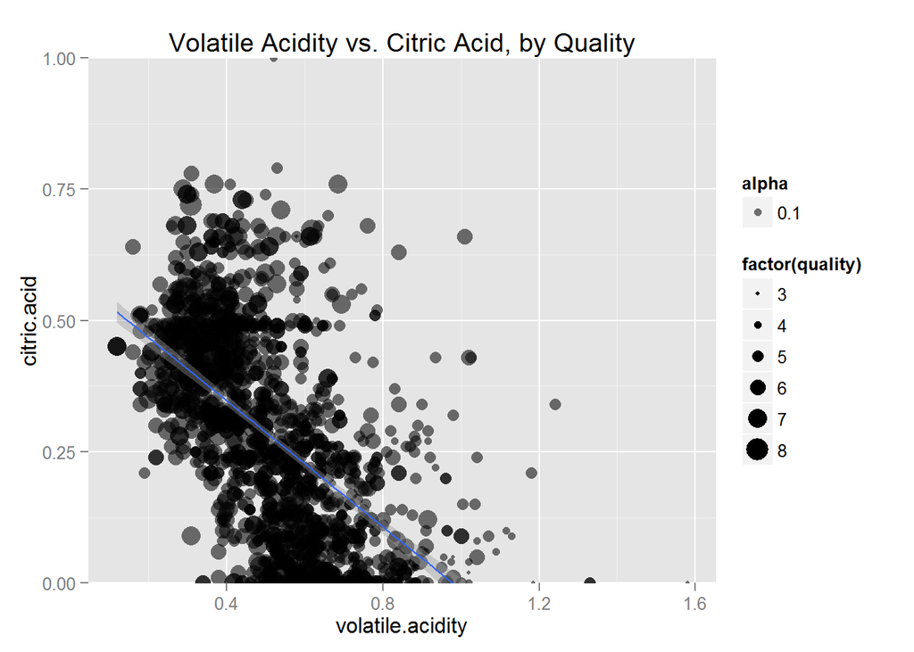

On the x axis there seems to be larger dots (higher score quality) to the left; whereas on the y axis it seems that there are dots of all sizes throughout. The relationship between volatile acidity and citric acid is shown in the plot by the smooth line.

I will facet this plot.

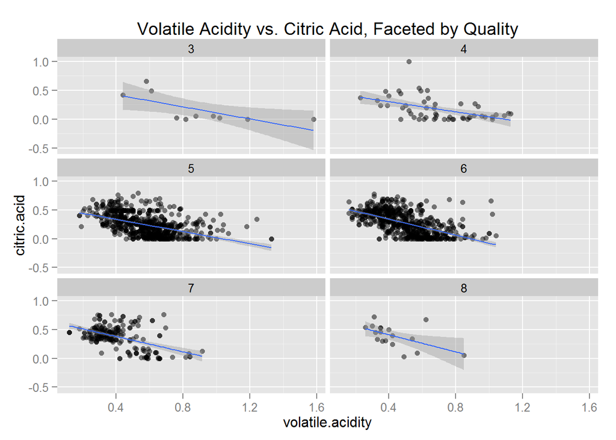

The relationship between volatile acidity and citric acid is consistent for all the quality scores. Since I am trying to build a model to predict quality, I confirm my idea of using only volatile acidity in my model.

Now, volatile acidity, alcohol, and quality. Alcohol and volatile acidity are the two variables with higher correlation to quality.

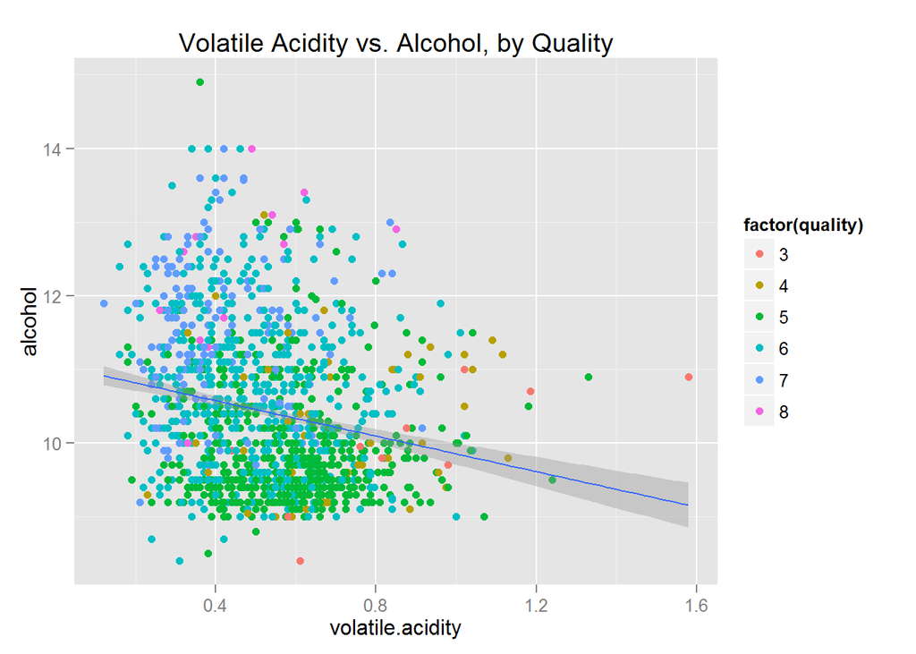

I will try a faceted plot

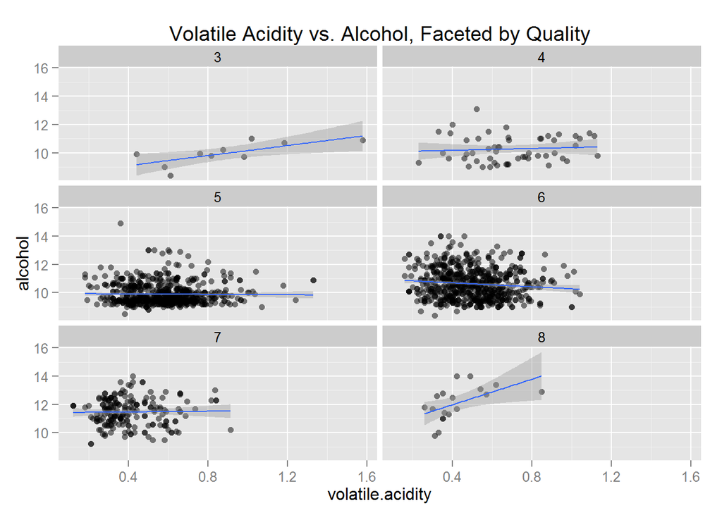

The relationship between alcohol and volatile acidity, for different qualities is not consistent. Therefore I confirm the use of these two variables in my model, for I will consider them as ‘independent’.

Now I will build the model: ‘m1’ is simply quality as a function of alcohol, ‘m2’ adds volatile acidity as an explanatory variable to ‘m1’, and ‘m3’ adds sulphates as an explanatory variable to ‘m2’.

```
##
## Calls:
## m1: lm(formula = quality ~ alcohol, data = red_wines)
## m2: lm(formula = quality ~ alcohol + volatile.acidity, data = red_wines)
## m3: lm(formula = quality ~ alcohol + volatile.acidity + sulphates,
##     data = red_wines)
##
## ===============================================
##                      m1        m2        m3
## -----------------------------------------------
## (Intercept)        1.875***  3.095***  2.611***
##                   (0.175)   (0.184)   (0.196)
## alcohol            0.361***  0.314***  0.309***
##                   (0.017)   (0.016)   (0.016)
## volatile.acidity            -1.384*** -1.221***
##                             (0.095)   (0.097)
## sulphates                              0.679***
##                                       (0.101)
## -----------------------------------------------
## R-squared             0.227     0.317     0.336
## adj. R-squared        0.226     0.316     0.335
## sigma                 0.710     0.668     0.659
## F                   468.267   370.379   268.912
## p                     0.000     0.000     0.000
## Log-likelihood    -1721.057 -1621.814 -1599.384
## Deviance            805.870   711.796   692.105
## AIC                3448.114  3251.628  3208.768
## BIC                3464.245  3273.136  3235.654
## N                  1599      1599      1599
## ===============================================
```

R^2 for m3 is only 0.336; however, all variables in the model are significant and independent.

# Multivariate Analysis

### Talk about some of the relationships you observed in this part of the investigation. Were there features that strengthened each other in terms of looking at your feature(s) of interest?

I could confirm the high correlation between volatile acidity and citric acid. Also, that alcohol and volatile acidity can be considered as independent varibles.

### Were there any interesting or surprising interactions between features?

Interactions confirmed the features described in previous sections.

### OPTIONAL: Did you create any models with your dataset? Discuss the strengths and limitations of your model.

Given the conditional median plots from the Bivariate Analysis section, a linear model was chosen to predict quality scores. There were initially five varibles of interest for this plot: alcohol, volatile acidity, sulphates, citric acid, and total sulfur dioxide. Total sulfur dioxide was discarded with its conditional median plot. Also volatile acidity and citric acid were found to have a strong relationship, given the plots for these variables and their relationship with quality, only volatile acidity was left in the model. This considerations gave rise to the ‘m3’ model with only three explanatory variables, alcohol, volatile acidity, and sulphates. The dataset can be thought as relatively small, so in order to avoid overfitting to this dataset, the relatively low R^2 value can be thought as sufficient. Also, bear in mind that even though given by experts, quality scores are subjective values; and most scores are either 5 or 6. Possibly, a better model could be built with a larger ddataset, and a quality score variable with larger variance.

# Final Plots and Summary

### Plot One

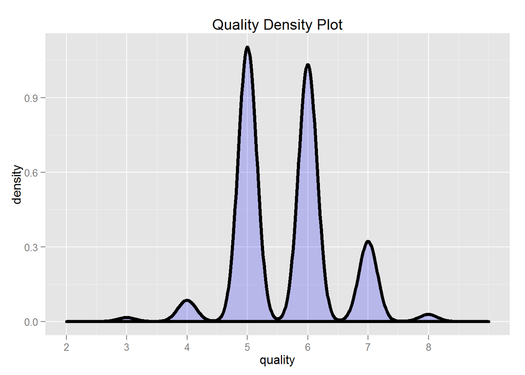

### Description One

Most quality scores are 5 or 6. There isn’t much variance in the variable I am trying to explain/predict.

### Plot Two

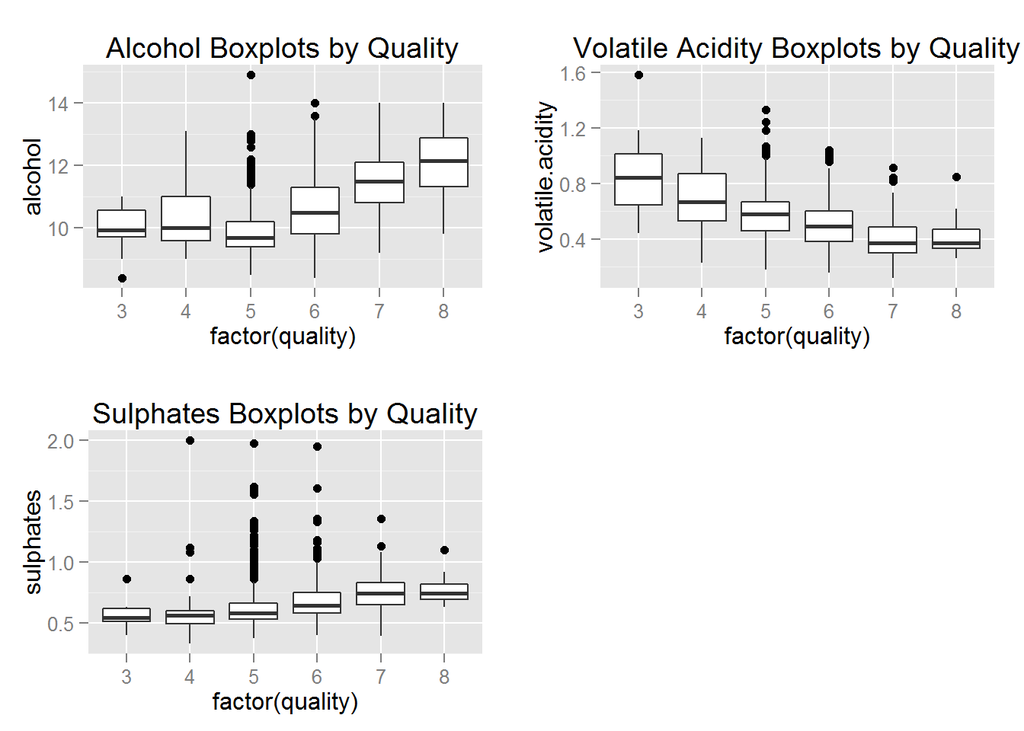

### Description Two

Boxplots of the three variables of the model by quality.

### Plot Three

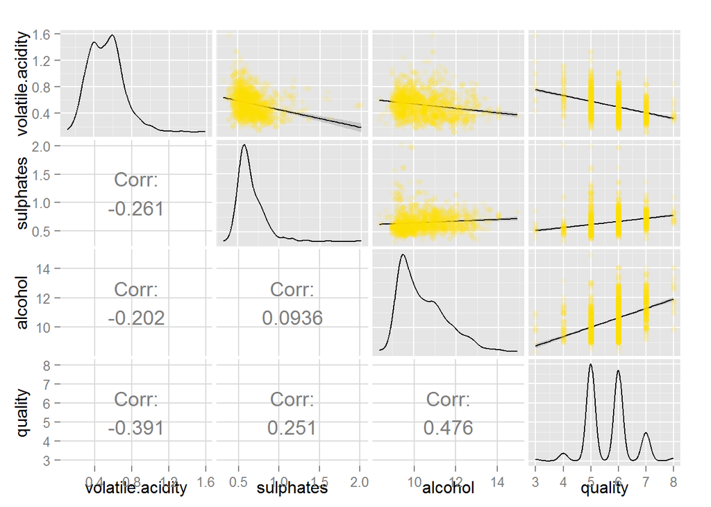

### Description Three

Variables in the model ‘m3’.

# Reflection

This dataset contains several chemical characteristics of red wines, and a quality varible that contains quality scores for each of the 1599 observations. Initially, keeping in mind that the final goal was to build a model that explained quality as a function of the chemical characteristics of red wines, a univariate exploration and analysis was conducted. The first important finding was that quality did not had too much variance; most of the scores were either 5 or 6. The fact that citric acid didn’t had a normal distribution aslo was important for its exclusion of the model at the end.

In the bivariate exploration and analysis, five potential variables were recognized as variables of interest for their correlation to quality. It was also found a strong correlation between two of the variables of interest, namely volatile acidity and citric acid. Finally, conditional median plots gave insight in the linear relationship of quality and that variables of interest, except for total sulfur dioxide.

In the last section of Multivariate exploration and analysis, the previous findings were confirmed and the model was built.